# Coursera - Reproducible Research Project

Max Morganti

October 5, 2017

This is a brief exploratory analysis of data from a personal activity monitoring device, found [here](https://d396qusza40orc.cloudfront.net/repdata%2Fdata%2Factivity.zip). It collects data at 5 minute intervals throughout the day. This file consists of two months of data from an anonymous individual during the months of October and November, 2012 and includes the number of steps taken in each 5 minute interval throughout each day.

### Loading and preprocessing the data

We will begin by loading in the data and taking a look at a sample of it.

```r
activity <- read.csv('activity.csv')
dim(activity)
```

```
## [1] 17568     3
```

```r
head(activity)
```

```
##   steps       date interval
## 1    NA 2012-10-01        0
## 2    NA 2012-10-01        5
## 3    NA 2012-10-01       10
## 4    NA 2012-10-01       15
## 5    NA 2012-10-01       20
## 6    NA 2012-10-01       25
```

We should convert the date column to the date class and add leading zeroes to the interval number so that we can properly convert it to a time later.

```r
activity$interval <- sprintf("%04d", activity$interval)
activity$date <- as.Date(as.character(activity$date), "%Y-%m-%d")
head(activity)
```

```
##   steps       date interval
## 1    NA 2012-10-01     0000
## 2    NA 2012-10-01     0005
## 3    NA 2012-10-01     0010
## 4    NA 2012-10-01     0015
## 5    NA 2012-10-01     0020
## 6    NA 2012-10-01     0025
```

It’s worrying that there are so many NA entries for ‘steps’, but if we look farther down, we see it does contain numeric data.

```r
activity[1000:1010,]
```

```
##      steps       date interval
## 1000     0 2012-10-04     1115
## 1001     0 2012-10-04     1120
## 1002   180 2012-10-04     1125
## 1003    21 2012-10-04     1130
## 1004     0 2012-10-04     1135
## 1005     0 2012-10-04     1140
## 1006     0 2012-10-04     1145
## 1007     0 2012-10-04     1150
## 1008     0 2012-10-04     1155
## 1009   160 2012-10-04     1200
## 1010    79 2012-10-04     1205
```

### What is mean total number of steps taken per day?

We can create a histogram to see the distribution of how many steps are taken each day. Use ‘tapply’ to sum the number of steps over each day.

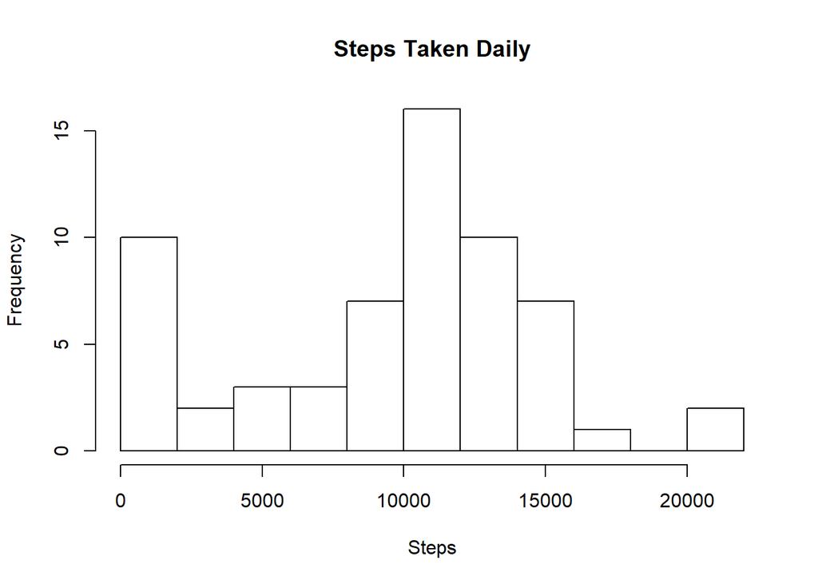

```r
steps_sum <- with(activity, tapply(steps, date, sum, na.rm = TRUE))
hist(steps_sum, breaks = 10, xlab = 'Steps', main = 'Steps Taken Daily')
```

And we can use basic statistical functions like ‘mean’ and ‘median’ on our sum vector to get more information on the average number of steps taken each day.

```r
mean(steps_sum, na.rm = TRUE)
```

```
## [1] 9354.23
```

```r
median(steps_sum, na.rm = TRUE)
```

```
## [1] 10395
```

### What is the average daily activity pattern?

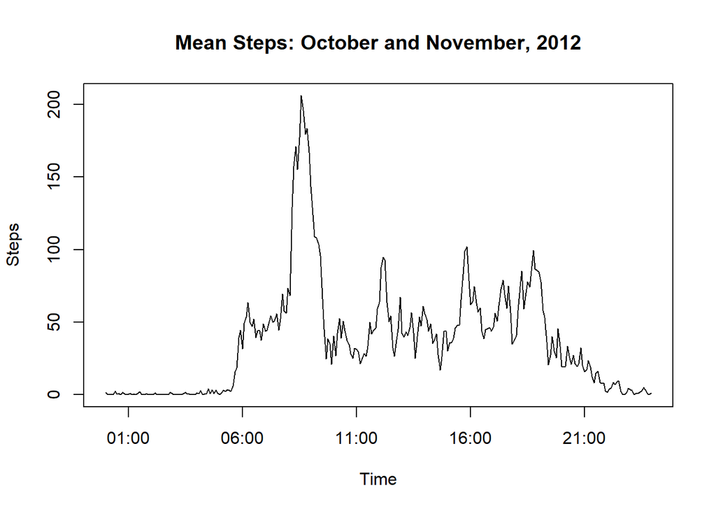

```r
interval_mean <- with(activity, tapply(steps, interval, mean, na.rm = TRUE))
plot(strptime(names(interval_mean), "%H%M"), interval_mean, type = 'l', xlab = 'Time', ylab = 'Steps', main = 'Mean Steps: October and November, 2012')
```

It is then easy to find which interval contains the maximum number of steps on average: 206.16 steps at 8:35 each day, which is index 104 of interval_mean.

```r
which.max(interval_mean)
```

```
## 0835
##  104
```

```r
max(interval_mean)
```

```
## [1] 206.1698
```

### Imputing missing values

Returning to the subject of NA’s, we should see how much of our data is missing and what percentage that corresponds to.

```r
sum(is.na(activity$steps))
```

```
## [1] 2304
```

```r
mean(is.na(activity$steps))
```

```
## [1] 0.1311475
```

Thirteen percent sounds like a non-negligable amount, so we should impute this missing data in some way. Here we will simply replace any missing values by the mean over all days for that corresponding interval. We loop over the whole ‘steps’ column for this operation and replace NA’s using the named array in which we stored the interval means earlier.

```r
for(i in 1:nrow(activity)) {
    if(is.na(activity[i,'steps'])) {
        interval <- activity[i, 'interval']
        activity[i, 'steps'] <- interval_mean[as.character(interval)]
    }
}
```

Now we take a look at the histogram again to see if this changed anything. It does seem to have narrowed the distribution, this is to be expected since we increased the number of values equal to the average of each interval. It also lowered the number of days in the lowest bin; this means that before that bin consisted of a large amount of days with mostly or only NA values. It is probably more accurate to treat those as average days, as we do here.

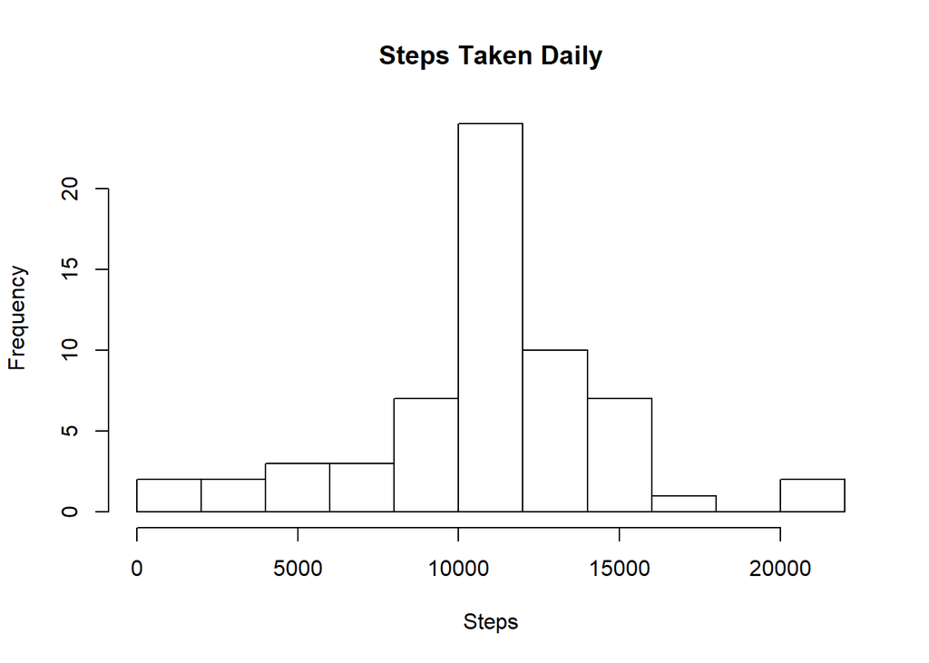

```r
steps_sum <- with(activity, tapply(steps, date, sum, na.rm = TRUE))
hist(steps_sum, breaks = 10, xlab = 'Steps', main = 'Steps Taken Daily')
```

### Are there differences in activity patterns between weekdays and weekends?

Finally, we want to compare activity levels during the weekend versus during weekdays. First, we add a new column to our data that identifies the type of day by using the ‘weekdays’ function and then reading the output string.

```r
day <- weekdays(activity$date)
activity$day_type <- ifelse(day == 'Saturday' | day == 'Sunday','Weekend', 'Weekday')
```

Now, we ‘tapply’ the mean over both day type and interval, then use the ‘melt’ function from the ‘reshape2’ package to reshape the data into a form where the interval information is contained in a single column so it can be more easily plotted.

```r
day_type_means <- with(activity, tapply(steps, list(day_type, interval), mean, na.rm = TRUE))
library(reshape2)
day_type_means <- melt(day_type_means)
names(day_type_means) <- c('day_type', 'interval', 'avg_steps')
day_type_means$interval <- sprintf("%04d", day_type_means$interval)
head(day_type_means)
```

```
##   day_type interval  avg_steps
## 1  Weekday     0000 2.25115304
## 2  Weekend     0000 0.21462264
## 3  Weekday     0005 0.44528302
## 4  Weekend     0005 0.04245283
## 5  Weekday     0010 0.17316562
## 6  Weekend     0010 0.01650943
```

Finally, we can use ‘ggplot2’ to create our comparison plot.

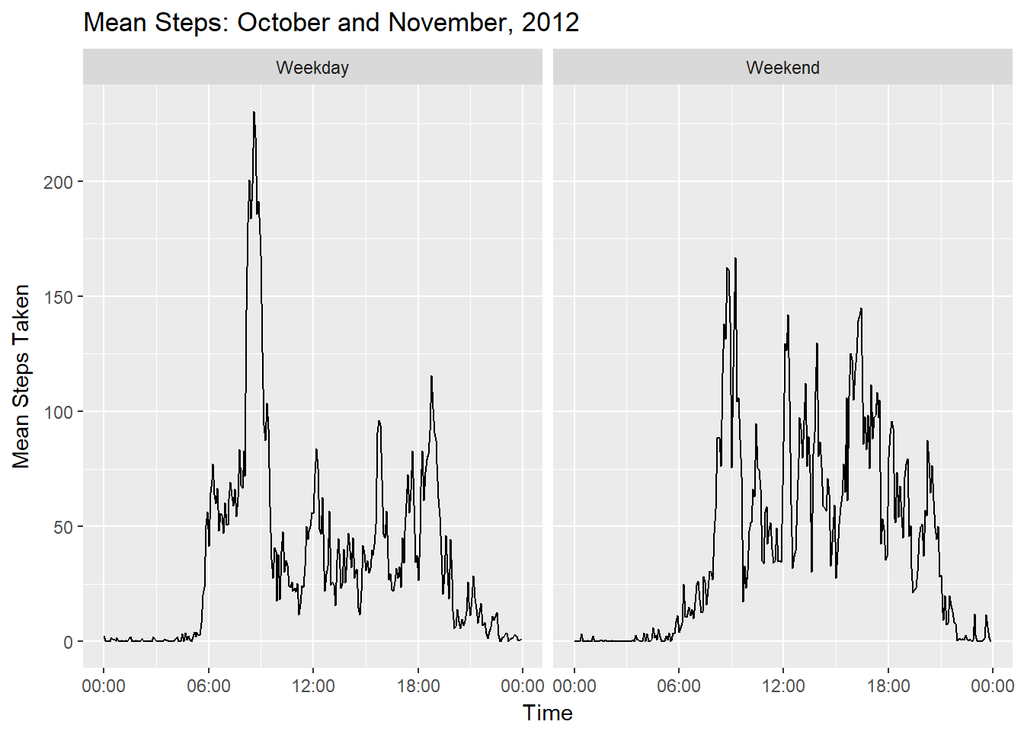

```r
library(ggplot2)
qplot(strptime(interval, "%H%M"), avg_steps, data = day_type_means, facets = .~day_type, geom = 'line', xlab = 'Time', ylab = 'Mean Steps Taken', main = 'Mean Steps: October and November, 2012') + scale_x_datetime(date_label = "%H:%M")
```